# pyspark_kafka_project (5)-Copy1

### Anomaly Detection in Server Logs

#### CS 5614: Big Data Engineering

#### By: Vanessa Eichensehr and Bradley Freedman

**Project Objective:**

Build a machine learning-based model that detects anomalies on a high volume high velocity log base.

```python
# Start Spark session

from pyspark.sql import SparkSession

spark = SparkSession.\
        builder.\
        appName("pyspark-kafka-streaming").\
        master("spark://spark-master:7077").\
        config("spark.jars.packages", "org.apache.spark:spark-sql-kafka-0-10_2.12:3.0.0"). \
        config("spark.executor.memory", "512m").\
        getOrCreate()
```

[output not shown]

**Step 1:** Load labeled training data

The training data was generated by our python script, log_generator.py. We injected anomalies into the script and labelled them as such. We aimed to have 5% anomalies in our training dataset, based on our research.

```python
training_df = spark.read.csv("/data/synthetic_with_anomalies_NEW.csv", header=True, inferSchema=True)
training_df.show(5)
```

```
[Stage 2:>                                                          (0 + 1) / 1]
```

```
+-------------+--------------------+------+--------------------+------+------+--------------------+--------------------+---------+-------------+
|           ip|                time|method|                path|status|  size|            referrer|          user_agent|anomalous|     category|
+-------------+--------------------+------+--------------------+------+------+--------------------+--------------------+---------+-------------+
| 54.36.149.86|2019-01-22 03:59:...|   GET|/image/8739/speci...|   200|179495|https://www.zanbi...|Mozilla/5.0 (X11;...|        0|not anomalous|
| 5.62.206.249|2019-01-22 03:59:...|   GET|      /settings/logo|   302|159434|https://www.zanbi...|Mozilla/5.0 (Wind...|        0|not anomalous|
| 54.36.149.16|2019-01-22 03:59:...|   GET|/product/4031/20/...|   302| 74066|https://www.zanbi...|Dalvik/2.1.0 (Lin...|        0|not anomalous|
|66.249.66.195|2019-01-22 03:59:...|   GET|/image/65274/prod...|   302| 66812|https://www-zanbi...|Mozilla/5.0 (Linu...|        0|not anomalous|
| 95.81.118.56|2019-01-22 03:59:...|   GET|/product/30275/59...|   301| 65979|https://www.zanbi...|Mozilla/5.0 (Wind...|        0|not anomalous|
+-------------+--------------------+------+--------------------+------+------+--------------------+--------------------+---------+-------------+
only showing top 5 rows
```

**Step 2:** Pre-process features

```python
!pip install numpy
```

```
WARNING: Running pip as the 'root' user can result in broken permissions and conflicting behaviour with the system package manager, possibly rendering your system unusable. It is recommended to use a virtual environment instead: https://pip.pypa.io/warnings/venv. Use the --root-user-action option if…
```

```python
from pyspark.ml.feature import StringIndexer, VectorAssembler
from pyspark.ml import Pipeline
from pyspark.sql.functions import unix_timestamp

# use UNIX time so it can be an integer
training_df = training_df.withColumn(
    "unix_time",
    unix_timestamp("time", "yyyy-MM-dd HH:mm:ss.SSS")
)

# Define all categorical fields to index
categorical_cols = ["ip", "method", "path", "referrer", "user_agent"]
indexers = [StringIndexer(inputCol=col, outputCol=col + "_idx", handleInvalid="keep") for col in categorical_cols]

# Update VectorAssembler to include it
assembler = VectorAssembler(
    inputCols=["status", "size", "unix_time"] + [col + "_idx" for col in ["ip", "method", "path", "referrer", "user_agent"]],
    outputCol="features"
)

# note that REQUEST_TYPE = method
# note that REQUEST ARGUMENT = path

label_indexer =  StringIndexer(inputCol="category", outputCol="label")

print(label_indexer)

print(training_df.columns)

# Combine steps
pipeline = Pipeline(stages=indexers + [assembler, label_indexer])
pipeline_model = pipeline.fit(training_df)

label_indexer_model = pipeline_model.stages[-1]
print("Label -> Index Mapping:")
for i, label in enumerate(label_indexer_model.labels):
    print(f"{i}: {label}")

# Check for unmapped labels
actual_labels = training_df.select("category").distinct().rdd.flatMap(lambda x: x).collect()
mapped_labels = set(label_indexer_model.labels)
unmapped_labels = set(actual_labels) - mapped_labels
print("Unmapped Labels:", unmapped_labels)

print("Pipeline fit completed")
pipeline_model.save("/data/pipeline_model_MULTI5")
print("Pipeline saved")

log_transformed = pipeline_model.transform(training_df)

# show whole dataframe
log_transformed.show(5)

# show features only
log_transformed.select("features").show(truncate=False)
```

```
StringIndexer_011635435af5
['ip', 'time', 'method', 'path', 'status', 'size', 'referrer', 'user_agent', 'anomalous', 'category', 'unix_time']
Label -> Index Mapping:
0: not anomalous
1: slow_burst
2: ddos
3: error_spike
4: cross_field
5: false_positive
6: size_anomaly
```

```
Unmapped Labels: set()
Pipeline fit completed
```

```
Pipeline saved
+-------------+--------------------+------+--------------------+------+------+--------------------+--------------------+---------+-------------+----------+------+----------+--------+------------+--------------+--------------------+-----+
|           ip|                time|method|                path|status|  size|            referrer|          user_agent|anomalous|     category| unix_time|ip_idx|method_idx|path_idx|referrer_idx|user_agent_idx|            features|label|
+-------------+--------------------+------+--------------------+------+------+--------------------+--------------------+---------+-------------+----------+------+----------+--------+------------+--------------+--------------------+-----+
| 54.36.149.86|2019-01-22 03:59:...|   GET|/image/8739/speci...|   200|179495|https://www.zanbi...|Mozilla/5.0 (X11;...|        0|not anomalous|1548129551|  79.0|       0.0|    59.0|        11.0|          25.0|[200.0,179495.0,1...|  0.0|
| 5.62.206.249|2019-01-22 03:59:...|   GET|      /settings/logo|   302|159434|https://www.zanbi...|Mozilla/5.0 (Wind...|        0|not anomalous|1548129551|   3.0|       0.0|   736.0|        19.0|          38.0|[302.0,159434.0,1...|  0.0|
| 54.36.149.16|2019-01-22 03:59:...|   GET|/product/4031/20/...|   302| 74066|https://www.zanbi...|Dalvik/2.1.0 (Lin...|        0|not anomalous|1548129551|  36.0|       0.0|   383.0|        34.0|          23.0|[302.0,74066.0,1....|  0.0|
|66.249.66.195|2019-01-22 03:59:...|   GET|/image/65274/prod...|   302| 66812|https://www-zanbi...|Mozilla/5.0 (Linu...|        0|not anomalous|1548129552|  45.0|       0.0|   272.0|        49.0|          37.0|[302.0,66812.0,1....|  0.0|
| 95.81.118.56|2019-01-22 03:59:...|   GET|/product/30275/59...|   301| 65979|https://www.zanbi...|Mozilla/5.0 (Wind...|        0|not anomalous|1548129552|  98.0|       0.0|   380.0|         0.0|          10.0|[301.0,65979.0,1....|  0.0|
+-------------+--------------------+------+--------------------+------+------+--------------------+--------------------+---------+-------------+----------+------+----------+--------+------------+--------------+--------------------+-----+
only showing top 5 rows

+-------------------------------------------------------+
|features                                               |
+-------------------------------------------------------+
|[200.0,179495.0,1.548129551E9,79.0,0.0,59.0,11.0,25.0] |
|[302.0,159434.0,1.548129551E9,3.0,0.0,736.0,19.0,38.0] |
|[302.0,74066.0,1.548129551E9,36.0,0.0,383.0,34.0,23.0] |
|[302.0,66812.0,1.548129552E9,45.0,0.0,272.0,49.0,37.0] |
|[301.0,65979.0,1.548129552E9,98.0,0.0,380.0,0.0,10.0]  |
|[301.0,176909.0,1.548129552E9,67.0,0.0,57.0,10.0,16.0] |
|[304.0,92224.0,1.548129552E9,84.0,0.0,562.0,40.0,18.0] |
|[302.0,53925.0,1.548129553E9,19.0,0.0,143.0,14.0,4.0]  |
|[304.0,11151.0,1.548129553E9,52.0,0.0,239.0,1.0,20.0]  |
|[200.0,181467.0,1.548129554E9,75.0,0.0,803.0,40.0,13.0]|
|[200.0,174015.0,1.548129554E9,27.0,0.0,114.0,33.0,17.0]|
|[304.0,123224.0,1.548129554E9,74.0,0.0,118.0,31.0,28.0]|
|[304.0,22350.0,1.548129554E9,23.0,0.0,423.0,50.0,27.0] |
|[404.0,58693.0,1.548129555E9,40.0,0.0,574.0,44.0,23.0] |
|[302.0,129259.0,1.548129555E9,92.0,0.0,615.0,33.0,2.0] |
|[200.0,129469.0,1.548129555E9,6.0,0.0,24.0,42.0,35.0]  |
|[301.0,106665.0,1.548129556E9,40.0,0.0,575.0,7.0,17.0] |
|[404.0,82569.0,1.548129556E9,64.0,0.0,585.0,35.0,45.0] |
|[302.0,92755.0,1.548129556E9,97.0,0.0,139.0,23.0,40.0] |
|[404.0,19443.0,1.548129557E9,24.0,0.0,320.0,38.0,15.0] |
+-------------------------------------------------------+
only showing top 20 rows
```

**Step 3:** Split into train and test sets (use random seed to get consistent results)

```python
train_data, test_data = log_transformed.randomSplit([0.8, 0.2], seed=42)
```

```python
# Random Forest
from pyspark.ml.classification import RandomForestClassifier

rf = RandomForestClassifier(
    featuresCol="features",
    labelCol="label",
    maxBins=1024  # default is 32, need to override it
)
rf_model = rf.fit(train_data)
```

```python
# Logistic Regression
from pyspark.ml.classification import LogisticRegression

lr = LogisticRegression(
    featuresCol="features",
    labelCol="label",
    maxIter=100,
    regParam=0.01
)
lr_model = lr.fit(train_data)
```

```
25/05/06 04:52:15 WARN BLAS: Failed to load implementation from: com.github.fommil.netlib.NativeSystemBLAS
25/05/06 04:52:15 WARN BLAS: Failed to load implementation from: com.github.fommil.netlib.NativeRefBLAS
```

```python
# Gradient Boosted Trees ONLY support binary classification
# from pyspark.ml.classification import GBTClassifier

# gbt = GBTClassifier(
#     featuresCol="features",
#     labelCol="label",
#     maxIter=20, # Number of trees (iterations)
#     maxDepth=5, # Max depth of each tree
#     maxBins=1024
# )
# # Train the model
# gbt_model = gbt.fit(train_data)
```

```python
# Multi-Layer Perceptron Classifier
from pyspark.ml.classification import MultilayerPerceptronClassifier

num_features = train_data.select("features").first().features.size
num_classes = 7
layers = [num_features, 10, num_classes]

mlpc = MultilayerPerceptronClassifier(
    featuresCol="features",
    labelCol="label",
    layers=layers,
    blockSize=128, # batch size
    seed=42,     # for reproduciblity
    maxIter=100
)

# Train the model
mlpc_model = mlpc.fit(train_data)
```

**Step 5:** Make predictions on test set

```python
rf_predictions = rf_model.transform(test_data)
lr_predictions = lr_model.transform(test_data)
# gbt_predictions = gbt_model.transform(test_data) #binary only
mlpc_predictions = mlpc_model.transform(test_data)
```

```python
!pip install pandas
!pip install matplotlib
```

[output not shown]

```
[Stage 152:==============================================>      (174 + 2) / 200]
```

```
Prediction Distribution for Random Forest:
      prediction  count
2    error_spike      7
0  not anomalous   1978
1     slow_burst     46
```

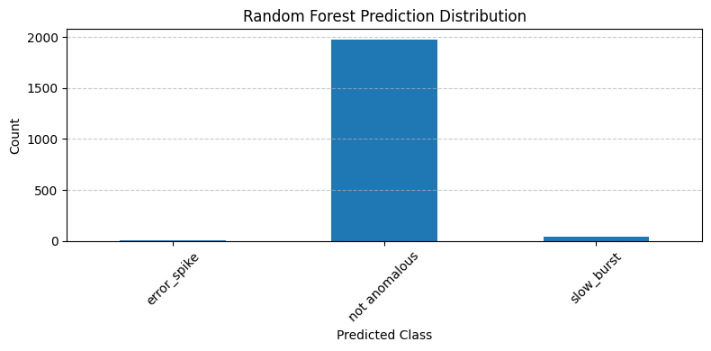

```
Prediction Distribution for Logistic Regression:
      prediction  count
0  not anomalous   2031
```

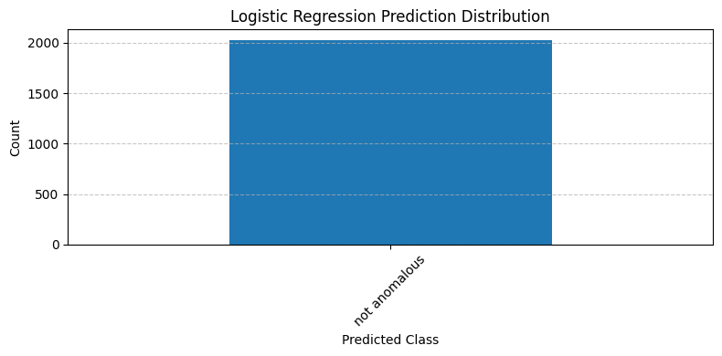

```
[Stage 156:========================================>            (153 + 2) / 200]
```

```
Prediction Distribution for MLP Classifier:
      prediction  count
0  not anomalous   2031
```

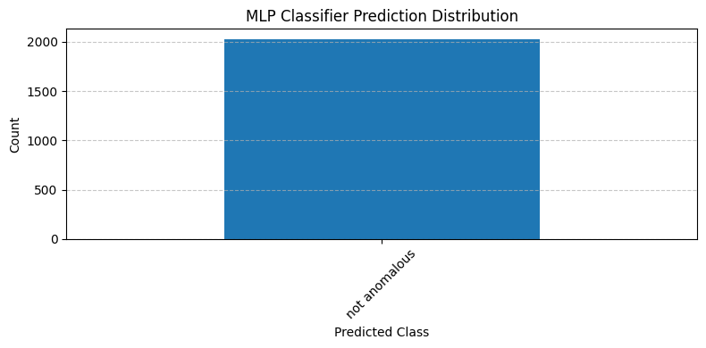

```python
import pandas as pd
import matplotlib.pyplot as plt

# print distribution of predictions
# Map class index to label
label_mapping = {
    0: "not anomalous",
    1: "slow_burst",
    2: "ddos",
    3: "error_spike",
    4: "cross_field",
    5: "false_positive",
    6: "size_anomaly"
}

def show_prediction_distribution(predictions_df, model_name):
    # Group by prediction and count
    pred_counts = predictions_df.groupBy("prediction").count().toPandas()

    # Map prediction index to class name
    pred_counts["prediction"] = pred_counts["prediction"].astype(int).map(label_mapping)

    # Sort for consistent ordering
    pred_counts = pred_counts.sort_values("prediction")

    print(f"\nPrediction Distribution for {model_name}:")
    print(pred_counts)

    # Optional bar plot
    pred_counts.set_index("prediction")["count"].plot(kind="bar", title=f"{model_name} Prediction Distribution", figsize=(8, 4))
    plt.ylabel("Count")
    plt.xlabel("Predicted Class")
    plt.xticks(rotation=45)
    plt.grid(axis="y", linestyle="--", alpha=0.7)
    plt.tight_layout()
    plt.show()

# Run for each model
show_prediction_distribution(rf_predictions, "Random Forest")
show_prediction_distribution(lr_predictions, "Logistic Regression")
show_prediction_distribution(mlpc_predictions, "MLP Classifier")
```

**Step 6:** Evaluate models' performances

```
Random Forest Metrics:
Accuracy:  0.977
Precision: 0.961
Recall:    0.977
F1 Score:  0.968

Logistic Regression Metrics:
Accuracy:  0.951
Precision: 0.904
Recall:    0.951
F1 Score:  0.927

MLP Classifier Metrics:
Accuracy:  0.951
Precision: 0.904
Recall:    0.951
F1 Score:  0.927
```

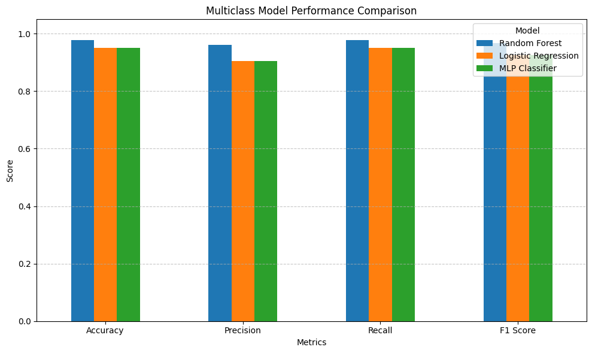

```python
import pandas as pd
import matplotlib.pyplot as plt
from pyspark.ml.evaluation import MulticlassClassificationEvaluator
from pyspark.sql.functions import col

# Class label mapping
label_mapping = {
   0: "not anomalous",
    1: "slow_burst",
    2: "ddos",
    3: "error_spike",
    4: "cross_field",
    5: "false_positive",
    6: "size_anomaly"
}

# Store results
model_results = []

def evaluate_multiclass_model(predictions, model_name):
    # Evaluators
    evaluator_precision = MulticlassClassificationEvaluator(labelCol="label", predictionCol="prediction", metricName="weightedPrecision")
    evaluator_recall = MulticlassClassificationEvaluator(labelCol="label", predictionCol="prediction", metricName="weightedRecall")
    evaluator_f1 = MulticlassClassificationEvaluator(labelCol="label", predictionCol="prediction", metricName="f1")
    evaluator_accuracy = MulticlassClassificationEvaluator(labelCol="label", predictionCol="prediction", metricName="accuracy")

    # Compute metrics
    accuracy = evaluator_accuracy.evaluate(predictions)
    precision = evaluator_precision.evaluate(predictions)
    recall = evaluator_recall.evaluate(predictions)
    f1 = evaluator_f1.evaluate(predictions)

    print(f"{model_name} Metrics:")
    print(f"Accuracy:  {accuracy:.3f}")
    print(f"Precision: {precision:.3f}")
    print(f"Recall:    {recall:.3f}")
    print(f"F1 Score:  {f1:.3f}\n")

    model_results.append({
        "Model": model_name,
        "Accuracy": accuracy,
        "Precision": precision,
        "Recall": recall,
        "F1 Score": f1
    })

# Evaluate your models
evaluate_multiclass_model(rf_predictions, "Random Forest")
evaluate_multiclass_model(lr_predictions, "Logistic Regression")
# evaluate_multiclass_model(gbt_predictions, "Gradient Boosted Tree")
evaluate_multiclass_model(mlpc_predictions, "MLP Classifier")

# Convert to DataFrame
results_df = pd.DataFrame(model_results)
results_df.set_index("Model", inplace=True)

# Plot: Models as bars, metrics on x-axis
results_df.T.plot(kind="bar", figsize=(10, 6))
plt.title("Multiclass Model Performance Comparison")
plt.xlabel("Metrics")
plt.ylabel("Score")
plt.ylim(0, 1.05)
plt.grid(axis='y', linestyle='--', alpha=0.7)
plt.xticks(rotation=0)
plt.legend(title="Model", loc="upper right")
plt.tight_layout()
plt.show()
```

**Step 8:** Save models for future use

```python
rf_model.save('/data/_rf_multi_classifier3')
lr_model.save('/data/_lr_multi_classifier3')
# gbt_model.save('/data/_gbt_multi_classifier')
mlpc_model.save('/data/_mlpc_multi_classifier3')
```

**Model Selection**: Random Forest is the only model that made predictions besides not anomalous; thus, we selected it.

```python
df_streamed_raw = (spark.readStream.format("kafka").option("kafka.bootstrap.servers", "kafka:9093").option("subscribe", "topic_test").load())
```

```python
from pyspark.sql.types import StringType
from pyspark.sql.functions import col

# convert byte stream to string
df_streamed_kv = (df_streamed_raw
    .withColumn("key", df_streamed_raw["key"].cast(StringType()))
    .withColumn("value", df_streamed_raw["value"].cast(StringType())))

test_query = (df_streamed_kv
              .writeStream \
              .format("memory") # output to memory \
              .outputMode("update") # only write updated rows to the sink \
              .queryName("test_query_table")  # Name of the in memory table \
              .start())
```

```
25/05/06 04:54:11 WARN StreamingQueryManager: Temporary checkpoint location created which is deleted normally when the query didn't fail: /tmp/temporary-5f3d16c6-a71a-4b40-89cf-7713620ebcc2. If it's required to delete it under any circumstances, please set spark.sql.streaming.forceDeleteTempCheckpoi…
```

The following cell should display a table populated with values being streamed from you Kafka producer.

```python
spark.sql("select * from test_query_table").show()
```

```
+----+--------------------+----------+---------+------+--------------------+-------------+
| key|               value|     topic|partition|offset|           timestamp|timestampType|
+----+--------------------+----------+---------+------+--------------------+-------------+
|1850|{"ip_address": "8...|topic_test|        0|203083|2025-05-06 04:54:...|            0|
|1851|{"ip_address": "5...|topic_test|        0|203084|2025-05-06 04:54:...|            0|
|1852|{"ip_address": "6...|topic_test|        0|203085|2025-05-06 04:54:...|            0|
|1853|{"ip_address": "9...|topic_test|        0|203086|2025-05-06 04:54:...|            0|
|1854|{"ip_address": "5...|topic_test|        0|203087|2025-05-06 04:54:...|            0|
|1855|{"ip_address": "5...|topic_test|        0|203088|2025-05-06 04:54:...|            0|
|1856|{"ip_address": "5...|topic_test|        0|203089|2025-05-06 04:54:...|            0|
|1857|{"ip_address": "5...|topic_test|        0|203090|2025-05-06 04:54:...|            0|
|1858|{"ip_address": "5...|topic_test|        0|203091|2025-05-06 04:54:...|            0|
|1859|{"ip_address": "3...|topic_test|        0|203092|2025-05-06 04:54:...|            0|
|1860|{"ip_address": "5...|topic_test|        0|203093|2025-05-06 04:54:...|            0|
|1861|{"ip_address": "5...|topic_test|        0|203094|2025-05-06 04:54:...|            0|
|1862|{"ip_address": "5...|topic_test|        0|203095|2025-05-06 04:54:...|            0|
|1863|{"ip_address": "5...|topic_test|        0|203096|2025-05-06 04:54:...|            0|
|1864|{"ip_address": "8...|topic_test|        0|203097|2025-05-06 04:54:...|            0|
|1865|{"ip_address": "4...|topic_test|        0|203098|2025-05-06 04:54:...|            0|
|1866|{"ip_address": "5...|topic_test|        0|203099|2025-05-06 04:54:...|            0|
|1867|{"ip_address": "6...|topic_test|        0|203100|2025-05-06 04:54:...|            0|
|1868|{"ip_address": "1...|topic_test|        0|203101|2025-05-06 04:54:...|            0|
|1869|{"ip_address": "5...|topic_test|        0|203102|2025-05-06 04:54:...|            0|
+----+--------------------+----------+---------+------+--------------------+-------------+
only showing top 20 rows
```

```python
test_query.stop()
```

The following cells contain code that take the streamed dataframe and formats it properly into a table. If any of the given cells fails, there might be a formatting issue with one of your previous solutions.

```python
from pyspark.sql.functions import from_json
from pyspark.sql.types import StructType, StructField, BooleanType, LongType, IntegerType

event_schema = StructType([
    StructField("ip_address", StringType()),
    StructField("date_time", StringType()),
    StructField("request_type", StringType()),
    StructField("request_arg", StringType()),
    StructField("status_code", StringType()),
    StructField("response_size", StringType()),
    StructField("referrer", StringType()),
    StructField("user_agent", StringType())
])

# Parse the events from JSON format
df_parsed = (df_streamed_kv
           # Sets schema for event data
           .withColumn("value", from_json("value", event_schema))
          )
```

```python
df_formatted = (df_parsed.select(
    col("key").alias("event_key")
    ,col("topic").alias("event_topic")
    ,col("timestamp").alias("event_timestamp")
    ,col("value.ip_address").alias("ip_address")
    ,col("value.date_time").alias("date_time")
    ,col("value.request_type").alias("request_type")
    ,col("value.request_arg").alias("request_arg")
    ,col("value.status_code").alias("status_code")
    ,col("value.response_size").cast(IntegerType()).alias("response_size")
    ,col("value.referrer").alias("referrer")
    ,col("value.user_agent").alias("user_agent")
))
```

```python
# Write the parsed data to console
query = (df_formatted.writeStream.format("console").outputMode("append").trigger(processingTime='5 seconds').start())
```

```
25/05/06 04:54:24 WARN StreamingQueryManager: Temporary checkpoint location created which is deleted normally when the query didn't fail: /tmp/temporary-ee38166b-3b64-45f7-aeea-63cd7e6523cd. If it's required to delete it under any circumstances, please set spark.sql.streaming.forceDeleteTempCheckpoi…
```

```
-------------------------------------------
Batch: 0
-------------------------------------------
+---------+-----------+---------------+----------+---------+------------+-----------+-----------+-------------+--------+----------+
|event_key|event_topic|event_timestamp|ip_address|date_time|request_type|request_arg|status_code|response_size|referrer|user_agent|
+---------+-----------+---------------+----------+---------+------------+-----------+-----------+-------------+--------+----------+
+---------+-----------+---------------+----------+---------+------------+-----------+-----------+-------------+--------+----------+

-------------------------------------------
Batch: 1
-------------------------------------------
+---------+-----------+--------------------+--------------+--------------------+------------+--------------------+-----------+-------------+--------------------+--------------------+
|event_key|event_topic|     event_timestamp|    ip_address|           date_time|request_type|         request_arg|status_code|response_size|            referrer|          user_agent|
+---------+-----------+--------------------+--------------+--------------------+------------+--------------------+-----------+-------------+--------------------+--------------------+
|     1969| topic_test|2025-05-06 04:54:...|216.244.66.248|22/Jan/2019:04:08...|         GET|/image/64709/prod...|        304|       113423|https://www-zanbi...|Mozilla/5.0 (Andr...|
|     1970| topic_test|2025-05-06 04:54:...|   31.56.96.51|22/Jan/2019:04:08...|         GET|/image/8727/speci...|        404|        98068|https://znbl.ir/s...|Dalvik/2.1.0 (Lin...|
+---------+-----------+--------------------+--------------+--------------------+------------+--------------------+-----------+-------------+--------------------+--------------------+

-------------------------------------------
Batch: 2
-------------------------------------------
+---------+-----------+--------------------+--------------+--------------------+------------+--------------------+-----------+-------------+--------------------+--------------------+
|event_key|event_topic|     event_timestamp|    ip_address|           date_time|request_type|         request_arg|status_code|response_size|            referrer|          user_agent|
+---------+-----------+--------------------+--------------+--------------------+------------+--------------------+-----------+-------------+--------------------+--------------------+
|     1971| topic_test|2025-05-06 04:54:...| 157.55.39.175|22/Jan/2019:04:08...|         GET|/m/filter/b99%2Cp...|        404|        96560|  https://torob.com/|Mozilla/5.0 (Linu...|
|     1972| topic_test|2025-05-06 04:54:...|  54.36.148.18|22/Jan/2019:04:08...|         GET|/filter/stexists,...|        304|        70151|https://www.zanbi...|Mozilla/5.0 (Linu...|
|     1973| topic_test|2025-05-06 04:54:...|  54.36.149.77|22/Jan/2019:04:08...|         GET|/image/6439/produ...|        304|        17687|https://www-zanbi...|Mozilla/5.0 (comp...|
|     1974| topic_test|2025-05-06 04:54:...| 66.249.66.194|22/Jan/2019:04:08...|         GET|/image/893/brand ...|        200|       165592|https://www.zanbi...|Dalvik/2.1.0 (Lin...|
|     1975| topic_test|2025-05-06 04:54:...| 5.209.127.187|22/Jan/2019:04:08...|         GET|/product/77690 HT...|        404|        69642|https://www.zanbi...|Dalvik/2.1.0 (Lin...|
|     1976| topic_test|2025-05-06 04:54:...|   5.78.180.75|22/Jan/2019:04:08...|         GET|/image/4576/produ...|        404|       125562|https://www.zanbi...|Mozilla/5.0 (Linu...|
```

[output cut: 16 more lines]

```python
# Print the name of active streams (This may be useful during debugging)
for s in spark.streams.active:
    print(f"ID:{s.id} | NAME:{s.name}")
```

```
ID:026264f3-c04e-4624-9e0b-68be628a6123 | NAME:None
```

```python
query.stop()
```

**Step 10:** Batch/Rolling window incoming data, make predictions on it using random forest model

```python
from pyspark.ml import PipelineModel
from pyspark.ml.classification import RandomForestClassificationModel
from pyspark.sql.functions import *
from pyspark.sql.functions import unix_timestamp

kafka_timestamp_format = "dd/MMM/yyyy:HH:mm:ss Z"

# Convert date_time from string to timestamp using the correct format
df_formatted = df_formatted.withColumn(
    "event_time",
    coalesce(
        to_timestamp(col("date_time"), kafka_timestamp_format),
    )
)

# Filter out rows where timestamp parsing failed (resulted in null)
df_formatted = df_formatted.filter(col("event_time").isNotNull())

# create windows
windowed_df = df_formatted.withWatermark("event_time", "10 seconds")

# adjust names to match the dataset used for training
renamed_df = windowed_df.selectExpr(
    "ip_address as ip",
    "request_type as method",
    "request_arg as path",
    "status_code as status",
    "response_size as size",
    "referrer",
    "user_agent",
    "event_time"
)

# convert data to ints and calculate unix_time
renamed_df = renamed_df \
    .withColumn("status", coalesce(col("status").cast("int"), lit(0))) \
    .withColumn("size", coalesce(col("size").cast("int"), lit(0))) \
    .withColumn("unix_time", unix_timestamp("event_time"))

# Filter again for safety before applying models, ensuring unix_time is not null
renamed_df = renamed_df.filter(col("unix_time").isNotNull())

# Load transformation pipeline and classifier
pipeline_model = PipelineModel.load("/data/pipeline_model_MULTI5")
rf_model = RandomForestClassificationModel.load("/data/_rf_multi_classifier3")
transformed_df = pipeline_model.transform(renamed_df)

# make predictions
predictions = rf_model.transform(transformed_df)

# Get only anomalies
anomalies_df = predictions.filter(col("prediction") != 0)

# Print full rows if anomalies are detected
query = anomalies_df.writeStream \
    .outputMode("append") \
    .format("console") \
    .option("truncate", False) \
    .trigger(processingTime="15 seconds") \
    .start()
```

```
25/05/06 04:59:09 WARN StringIndexerModel: Input column category does not exist during transformation. Skip StringIndexerModel for this column.
25/05/06 04:59:09 WARN StreamingQueryManager: Temporary checkpoint location created which is deleted normally when the query didn't fail: /tmp/temporary-be1edf51-fbcd-45d5-a1bf-497d21dc7906. If it's required to delete it under any circumstances, please set spark.sql.streaming.forceDeleteTempCheckpoi…
```

```
-------------------------------------------
Batch: 0
-------------------------------------------
+---+------+----+------+----+--------+----------+----------+---------+------+----------+--------+------------+--------------+--------+-------------+-----------+----------+
|ip |method|path|status|size|referrer|user_agent|event_time|unix_time|ip_idx|method_idx|path_idx|referrer_idx|user_agent_idx|features|rawPrediction|probability|prediction|
+---+------+----+------+----+--------+----------+----------+---------+------+----------+--------+------------+--------------+--------+-------------+-----------+----------+
+---+------+----+------+----+--------+----------+----------+---------+------+----------+--------+------------+--------------+--------+-------------+-----------+----------+

-------------------------------------------
Batch: 1
-------------------------------------------
+---+------+----+------+----+--------+----------+----------+---------+------+----------+--------+------------+--------------+--------+-------------+-----------+----------+
|ip |method|path|status|size|referrer|user_agent|event_time|unix_time|ip_idx|method_idx|path_idx|referrer_idx|user_agent_idx|features|rawPrediction|probability|prediction|
+---+------+----+------+----+--------+----------+----------+---------+------+----------+--------+------------+--------------+--------+-------------+-----------+----------+
+---+------+----+------+----+--------+----------+----------+---------+------+----------+--------+------------+--------------+--------+-------------+-----------+----------+

-------------------------------------------
Batch: 2
-------------------------------------------
+-------------+------+------------------------------------------------+------+----+-----------------------------------+---------------------------------------------+-------------------+----------+------+----------+--------+------------+--------------+-------------------------------------------------…
|ip           |method|path                                            |status|size|referrer                           |user_agent                                   |event_time         |unix_time |ip_idx|method_idx|path_idx|referrer_idx|user_agent_idx|features                                         …
+-------------+------+------------------------------------------------+------+----+-----------------------------------+---------------------------------------------+-------------------+----------+------+----------+--------+------------+--------------+-------------------------------------------------…
|54.36.148.237|HEAD  |/static/js/accordion.js?_=1548117035128 HTTP/1.1|302   |50  |https://www.zanbil.ir/m/filter/b113|Barkrowler/0.9 (+http://www.exensa.com/crawl)|2019-01-22 00:53:37|1548118417|50.0  |1.0       |861.0   |24.0        |14.0          |[302.0,50.0,1.548118417E9,50.0,1.0,861.0,24.0,14.…
+-------------+------+------------------------------------------------+------+----+-----------------------------------+---------------------------------------------+-------------------+----------+------+----------+--------+------------+--------------+-------------------------------------------------…

-------------------------------------------
Batch: 3
-------------------------------------------
+-------------+------+--------------------------+------+----+--------------------------------------------------------------------------------------------------------------------------------------------------------------+--------------------------------------------------------------------------------…
|ip           |method|path                      |status|size|referrer                                                                                                                                                      |user_agent                                                                      …
```

[output cut: 16 more lines]

```python
query.stop()
```